# Breast Cancer Analysis and ML Model

## Introduction

Breast cancer is one of the **most common** forms of cancer in the world. Some breast cancer statistics from the [American Cancer Society](https://www.cancer.org/cancer/breast-cancer/about/how-common-is-breast-cancer.html#:~:text=Trends%20in%20breast%20cancer%20deaths&text=The%20chance%20that%20a%20woman,down%20by%201%25%20per%20year.) include:

- In 2021, approx. `281,500` **new cases** of *invasive* breast cancer will be diagnosed in women.
- In 2021, approx. `43,600` women will **die** from breast cancer.
- Breast cancer is the second **leading cause of cancer death** in women.
- The **death rate** of breast cancer is approx. *1 in 39* (3.6%).

Some quick statistics regarding cancer in general are:

- In 2018, `12.3%` of *total* cancer cases in the world were from breast cancer ([World Cancer Research Fund](https://www.wcrf.org/dietandcancer/worldwide-cancer-data/)).
- In 2018, `25.4%` of *total* cancers in women were from breast cancer ([World Cancer Research Fund](https://www.wcrf.org/dietandcancer/worldwide-cancer-data/)).

### About this Analysis

This analysis aims to visually represent breast cancer data, statistically analyze that data, and create a ML model to predict benign or malignant breast tissue based on multiple factors.

## Data Processing

**Section Goals:**

- Load data into variable to use
- Visualize the data ina tabular format

```python
import pandas as pd
import matplotlib.pyplot as plt
import seaborn as sns
import statistics
import warnings
warnings.filterwarnings('ignore')
from sklearn.model_selection import train_test_split
from sklearn.ensemble import RandomForestClassifier
from sklearn.metrics import f1_score,confusion_matrix, accuracy_score
from sklearn.feature_selection import RFE
```

```python
cancer_data = pd.read_csv("data.csv")
```

```python
cancer_data
```

|  | id | diagnosis | radius_mean | texture_mean | perimeter_mean | area_mean | smoothness_mean | compactness_mean | concavity_mean | concave points_mean | ... | texture_worst | perimeter_worst | area_worst | smoothness_worst | compactness_worst | concavity_worst | concave points_worst | symmetry_worst | fractal_dimension_worst | Unnamed: 32 |
| --- | --- | --- | --- | --- | --- | --- | --- | --- | --- | --- | --- | --- | --- | --- | --- | --- | --- | --- | --- | --- | --- |
| 0 | 842302 | M | 17.99 | 10.38 | 122.80 | 1001.0 | 0.11840 | 0.27760 | 0.30010 | 0.14710 | ... | 17.33 | 184.60 | 2019.0 | 0.16220 | 0.66560 | 0.7119 | 0.2654 | 0.4601 | 0.11890 | NaN |
| 1 | 842517 | M | 20.57 | 17.77 | 132.90 | 1326.0 | 0.08474 | 0.07864 | 0.08690 | 0.07017 | ... | 23.41 | 158.80 | 1956.0 | 0.12380 | 0.18660 | 0.2416 | 0.1860 | 0.2750 | 0.08902 | NaN |
| 2 | 84300903 | M | 19.69 | 21.25 | 130.00 | 1203.0 | 0.10960 | 0.15990 | 0.19740 | 0.12790 | ... | 25.53 | 152.50 | 1709.0 | 0.14440 | 0.42450 | 0.4504 | 0.2430 | 0.3613 | 0.08758 | NaN |
| 3 | 84348301 | M | 11.42 | 20.38 | 77.58 | 386.1 | 0.14250 | 0.28390 | 0.24140 | 0.10520 | ... | 26.50 | 98.87 | 567.7 | 0.20980 | 0.86630 | 0.6869 | 0.2575 | 0.6638 | 0.17300 | NaN |
| 4 | 84358402 | M | 20.29 | 14.34 | 135.10 | 1297.0 | 0.10030 | 0.13280 | 0.19800 | 0.10430 | ... | 16.67 | 152.20 | 1575.0 | 0.13740 | 0.20500 | 0.4000 | 0.1625 | 0.2364 | 0.07678 | NaN |
| ... | ... | ... | ... | ... | ... | ... | ... | ... | ... | ... | ... | ... | ... | ... | ... | ... | ... | ... | ... | ... | ... |
| 564 | 926424 | M | 21.56 | 22.39 | 142.00 | 1479.0 | 0.11100 | 0.11590 | 0.24390 | 0.13890 | ... | 26.40 | 166.10 | 2027.0 | 0.14100 | 0.21130 | 0.4107 | 0.2216 | 0.2060 | 0.07115 | NaN |
| 565 | 926682 | M | 20.13 | 28.25 | 131.20 | 1261.0 | 0.09780 | 0.10340 | 0.14400 | 0.09791 | ... | 38.25 | 155.00 | 1731.0 | 0.11660 | 0.19220 | 0.3215 | 0.1628 | 0.2572 | 0.06637 | NaN |
| 566 | 926954 | M | 16.60 | 28.08 | 108.30 | 858.1 | 0.08455 | 0.10230 | 0.09251 | 0.05302 | ... | 34.12 | 126.70 | 1124.0 | 0.11390 | 0.30940 | 0.3403 | 0.1418 | 0.2218 | 0.07820 | NaN |
| 567 | 927241 | M | 20.60 | 29.33 | 140.10 | 1265.0 | 0.11780 | 0.27700 | 0.35140 | 0.15200 | ... | 39.42 | 184.60 | 1821.0 | 0.16500 | 0.86810 | 0.9387 | 0.2650 | 0.4087 | 0.12400 | NaN |
| 568 | 92751 | B | 7.76 | 24.54 | 47.92 | 181.0 | 0.05263 | 0.04362 | 0.00000 | 0.00000 | ... | 30.37 | 59.16 | 268.6 | 0.08996 | 0.06444 | 0.0000 | 0.0000 | 0.2871 | 0.07039 | NaN |

569 rows × 33 columns

```python
cancer_data.head()
```

|  | id | diagnosis | radius_mean | texture_mean | perimeter_mean | area_mean | smoothness_mean | compactness_mean | concavity_mean | concave points_mean | ... | texture_worst | perimeter_worst | area_worst | smoothness_worst | compactness_worst | concavity_worst | concave points_worst | symmetry_worst | fractal_dimension_worst | Unnamed: 32 |
| --- | --- | --- | --- | --- | --- | --- | --- | --- | --- | --- | --- | --- | --- | --- | --- | --- | --- | --- | --- | --- | --- |
| 0 | 842302 | M | 17.99 | 10.38 | 122.80 | 1001.0 | 0.11840 | 0.27760 | 0.3001 | 0.14710 | ... | 17.33 | 184.60 | 2019.0 | 0.1622 | 0.6656 | 0.7119 | 0.2654 | 0.4601 | 0.11890 | NaN |
| 1 | 842517 | M | 20.57 | 17.77 | 132.90 | 1326.0 | 0.08474 | 0.07864 | 0.0869 | 0.07017 | ... | 23.41 | 158.80 | 1956.0 | 0.1238 | 0.1866 | 0.2416 | 0.1860 | 0.2750 | 0.08902 | NaN |
| 2 | 84300903 | M | 19.69 | 21.25 | 130.00 | 1203.0 | 0.10960 | 0.15990 | 0.1974 | 0.12790 | ... | 25.53 | 152.50 | 1709.0 | 0.1444 | 0.4245 | 0.4504 | 0.2430 | 0.3613 | 0.08758 | NaN |
| 3 | 84348301 | M | 11.42 | 20.38 | 77.58 | 386.1 | 0.14250 | 0.28390 | 0.2414 | 0.10520 | ... | 26.50 | 98.87 | 567.7 | 0.2098 | 0.8663 | 0.6869 | 0.2575 | 0.6638 | 0.17300 | NaN |
| 4 | 84358402 | M | 20.29 | 14.34 | 135.10 | 1297.0 | 0.10030 | 0.13280 | 0.1980 | 0.10430 | ... | 16.67 | 152.20 | 1575.0 | 0.1374 | 0.2050 | 0.4000 | 0.1625 | 0.2364 | 0.07678 | NaN |

5 rows × 33 columns

```python
cancer_data.tail()
```

|  | id | diagnosis | radius_mean | texture_mean | perimeter_mean | area_mean | smoothness_mean | compactness_mean | concavity_mean | concave points_mean | ... | texture_worst | perimeter_worst | area_worst | smoothness_worst | compactness_worst | concavity_worst | concave points_worst | symmetry_worst | fractal_dimension_worst | Unnamed: 32 |
| --- | --- | --- | --- | --- | --- | --- | --- | --- | --- | --- | --- | --- | --- | --- | --- | --- | --- | --- | --- | --- | --- |
| 564 | 926424 | M | 21.56 | 22.39 | 142.00 | 1479.0 | 0.11100 | 0.11590 | 0.24390 | 0.13890 | ... | 26.40 | 166.10 | 2027.0 | 0.14100 | 0.21130 | 0.4107 | 0.2216 | 0.2060 | 0.07115 | NaN |
| 565 | 926682 | M | 20.13 | 28.25 | 131.20 | 1261.0 | 0.09780 | 0.10340 | 0.14400 | 0.09791 | ... | 38.25 | 155.00 | 1731.0 | 0.11660 | 0.19220 | 0.3215 | 0.1628 | 0.2572 | 0.06637 | NaN |
| 566 | 926954 | M | 16.60 | 28.08 | 108.30 | 858.1 | 0.08455 | 0.10230 | 0.09251 | 0.05302 | ... | 34.12 | 126.70 | 1124.0 | 0.11390 | 0.30940 | 0.3403 | 0.1418 | 0.2218 | 0.07820 | NaN |
| 567 | 927241 | M | 20.60 | 29.33 | 140.10 | 1265.0 | 0.11780 | 0.27700 | 0.35140 | 0.15200 | ... | 39.42 | 184.60 | 1821.0 | 0.16500 | 0.86810 | 0.9387 | 0.2650 | 0.4087 | 0.12400 | NaN |
| 568 | 92751 | B | 7.76 | 24.54 | 47.92 | 181.0 | 0.05263 | 0.04362 | 0.00000 | 0.00000 | ... | 30.37 | 59.16 | 268.6 | 0.08996 | 0.06444 | 0.0000 | 0.0000 | 0.2871 | 0.07039 | NaN |

5 rows × 33 columns

## Data Verification

**Section Goals:**

- Verify data through multiple checks
  - Check number of columns and rows
  - Check for any missing data
  - Check the value types in each column

```python
cancer_data.info()
```

```
<class 'pandas.core.frame.DataFrame'>
RangeIndex: 569 entries, 0 to 568
Data columns (total 33 columns):
 #   Column                   Non-Null Count  Dtype
---  ------                   --------------  -----
 0   id                       569 non-null    int64
 1   diagnosis                569 non-null    object
 2   radius_mean              569 non-null    float64
 3   texture_mean             569 non-null    float64
 4   perimeter_mean           569 non-null    float64
 5   area_mean                569 non-null    float64
 6   smoothness_mean          569 non-null    float64
 7   compactness_mean         569 non-null    float64
 8   concavity_mean           569 non-null    float64
 9   concave points_mean      569 non-null    float64
```

[output cut: 25 more lines]

```python
cancer_data.columns
```

```
Index(['id', 'diagnosis', 'radius_mean', 'texture_mean', 'perimeter_mean',
       'area_mean', 'smoothness_mean', 'compactness_mean', 'concavity_mean',
       'concave points_mean', 'symmetry_mean', 'fractal_dimension_mean',
       'radius_se', 'texture_se', 'perimeter_se', 'area_se', 'smoothness_se',
       'compactness_se', 'concavity_se', 'concave points_se', 'symmetry_se',
       'fractal_dimension_se', 'radius_worst', 'texture_worst',
       'perimeter_worst', 'area_worst', 'smoothness_worst',
       'compactness_worst', 'concavity_worst', 'concave points_worst',
       'symmetry_worst', 'fractal_dimension_worst', 'Unnamed: 32'],
      dtype='object')
```

```python
print(f"Number of columns: {len(cancer_data.columns)}")
```

```
Number of columns: 33
```

```python
print(f"Number of rows: {len(cancer_data)}")
```

```
Number of rows: 569
```

```python
cancer_data.isna().sum()
```

```
id                           0
diagnosis                    0
radius_mean                  0
texture_mean                 0
perimeter_mean               0
area_mean                    0
smoothness_mean              0
compactness_mean             0
concavity_mean               0
concave points_mean          0
symmetry_mean                0
fractal_dimension_mean       0
radius_se                    0
texture_se                   0
perimeter_se                 0
area_se                      0
smoothness_se                0
compactness_se               0
concavity_se                 0
concave points_se            0
symmetry_se                  0
fractal_dimension_se         0
radius_worst                 0
texture_worst                0
perimeter_worst              0
area_worst                   0
smoothness_worst             0
compactness_worst            0
concavity_worst              0
concave points_worst         0
symmetry_worst               0
fractal_dimension_worst      0
Unnamed: 32                569
dtype: int64
```

```python
cancer_data.dtypes
```

```
id                           int64
diagnosis                   object
radius_mean                float64
texture_mean               float64
perimeter_mean             float64
area_mean                  float64
smoothness_mean            float64
compactness_mean           float64
concavity_mean             float64
concave points_mean        float64
symmetry_mean              float64
fractal_dimension_mean     float64
radius_se                  float64
texture_se                 float64
perimeter_se               float64
area_se                    float64
smoothness_se              float64
compactness_se             float64
concavity_se               float64
concave points_se          float64
symmetry_se                float64
fractal_dimension_se       float64
radius_worst               float64
texture_worst              float64
perimeter_worst            float64
area_worst                 float64
smoothness_worst           float64
compactness_worst          float64
concavity_worst            float64
concave points_worst       float64
symmetry_worst             float64
fractal_dimension_worst    float64
Unnamed: 32                float64
dtype: object
```

## Data Cleaning

**Section Goals:**

- Change values in `diagnosis` from `object` to `int64` (from characters to numbers)
- Remove unnecessary columns

```python
print(cancer_data["diagnosis"].unique())
```

```
['M' 'B']
```

```python
diagnosis = []
for i in range(len(cancer_data["diagnosis"])):
    if cancer_data["diagnosis"][i] == "B":
        diagnosis.append(0)
    else:
        diagnosis.append(1)
del cancer_data["diagnosis"]
cancer_data["diagnosis"] = diagnosis
```

```python
cancer_data["diagnosis"]
```

```
0      1
1      1
2      1
3      1
4      1
      ..
564    1
565    1
566    1
567    1
568    0
Name: diagnosis, Length: 569, dtype: int64
```

```python
cancer_data.dtypes
```

```
id                           int64
radius_mean                float64
texture_mean               float64
perimeter_mean             float64
area_mean                  float64
smoothness_mean            float64
compactness_mean           float64
concavity_mean             float64
concave points_mean        float64
symmetry_mean              float64
fractal_dimension_mean     float64
radius_se                  float64
texture_se                 float64
perimeter_se               float64
area_se                    float64
smoothness_se              float64
compactness_se             float64
concavity_se               float64
concave points_se          float64
symmetry_se                float64
fractal_dimension_se       float64
radius_worst               float64
texture_worst              float64
perimeter_worst            float64
area_worst                 float64
smoothness_worst           float64
compactness_worst          float64
concavity_worst            float64
concave points_worst       float64
symmetry_worst             float64
fractal_dimension_worst    float64
Unnamed: 32                float64
diagnosis                    int64
dtype: object
```

```python
removable_features = ["id", "Unnamed: 32"]
cancer_data.drop(removable_features, axis=1, inplace=True)
```

```python
cancer_data
```

|  | radius_mean | texture_mean | perimeter_mean | area_mean | smoothness_mean | compactness_mean | concavity_mean | concave points_mean | symmetry_mean | fractal_dimension_mean | ... | texture_worst | perimeter_worst | area_worst | smoothness_worst | compactness_worst | concavity_worst | concave points_worst | symmetry_worst | fractal_dimension_worst | diagnosis |
| --- | --- | --- | --- | --- | --- | --- | --- | --- | --- | --- | --- | --- | --- | --- | --- | --- | --- | --- | --- | --- | --- |
| 0 | 17.99 | 10.38 | 122.80 | 1001.0 | 0.11840 | 0.27760 | 0.30010 | 0.14710 | 0.2419 | 0.07871 | ... | 17.33 | 184.60 | 2019.0 | 0.16220 | 0.66560 | 0.7119 | 0.2654 | 0.4601 | 0.11890 | 1 |
| 1 | 20.57 | 17.77 | 132.90 | 1326.0 | 0.08474 | 0.07864 | 0.08690 | 0.07017 | 0.1812 | 0.05667 | ... | 23.41 | 158.80 | 1956.0 | 0.12380 | 0.18660 | 0.2416 | 0.1860 | 0.2750 | 0.08902 | 1 |
| 2 | 19.69 | 21.25 | 130.00 | 1203.0 | 0.10960 | 0.15990 | 0.19740 | 0.12790 | 0.2069 | 0.05999 | ... | 25.53 | 152.50 | 1709.0 | 0.14440 | 0.42450 | 0.4504 | 0.2430 | 0.3613 | 0.08758 | 1 |
| 3 | 11.42 | 20.38 | 77.58 | 386.1 | 0.14250 | 0.28390 | 0.24140 | 0.10520 | 0.2597 | 0.09744 | ... | 26.50 | 98.87 | 567.7 | 0.20980 | 0.86630 | 0.6869 | 0.2575 | 0.6638 | 0.17300 | 1 |
| 4 | 20.29 | 14.34 | 135.10 | 1297.0 | 0.10030 | 0.13280 | 0.19800 | 0.10430 | 0.1809 | 0.05883 | ... | 16.67 | 152.20 | 1575.0 | 0.13740 | 0.20500 | 0.4000 | 0.1625 | 0.2364 | 0.07678 | 1 |
| ... | ... | ... | ... | ... | ... | ... | ... | ... | ... | ... | ... | ... | ... | ... | ... | ... | ... | ... | ... | ... | ... |
| 564 | 21.56 | 22.39 | 142.00 | 1479.0 | 0.11100 | 0.11590 | 0.24390 | 0.13890 | 0.1726 | 0.05623 | ... | 26.40 | 166.10 | 2027.0 | 0.14100 | 0.21130 | 0.4107 | 0.2216 | 0.2060 | 0.07115 | 1 |
| 565 | 20.13 | 28.25 | 131.20 | 1261.0 | 0.09780 | 0.10340 | 0.14400 | 0.09791 | 0.1752 | 0.05533 | ... | 38.25 | 155.00 | 1731.0 | 0.11660 | 0.19220 | 0.3215 | 0.1628 | 0.2572 | 0.06637 | 1 |
| 566 | 16.60 | 28.08 | 108.30 | 858.1 | 0.08455 | 0.10230 | 0.09251 | 0.05302 | 0.1590 | 0.05648 | ... | 34.12 | 126.70 | 1124.0 | 0.11390 | 0.30940 | 0.3403 | 0.1418 | 0.2218 | 0.07820 | 1 |
| 567 | 20.60 | 29.33 | 140.10 | 1265.0 | 0.11780 | 0.27700 | 0.35140 | 0.15200 | 0.2397 | 0.07016 | ... | 39.42 | 184.60 | 1821.0 | 0.16500 | 0.86810 | 0.9387 | 0.2650 | 0.4087 | 0.12400 | 1 |
| 568 | 7.76 | 24.54 | 47.92 | 181.0 | 0.05263 | 0.04362 | 0.00000 | 0.00000 | 0.1587 | 0.05884 | ... | 30.37 | 59.16 | 268.6 | 0.08996 | 0.06444 | 0.0000 | 0.0000 | 0.2871 | 0.07039 | 0 |

569 rows × 31 columns

## Statistics

**Section Goals:**

- List the *standard deviation* of each column
- List the *average* of each column
- List the four *medians* of each column
- List other statistical measurements for each column (in tabular format)

### Standard Deviation

```python
for column in cancer_data:
    print(f"The standard deviation of |{cancer_data[column].name}| is ----- {statistics.stdev(cancer_data[column])}")
```

```
The standard deviation of |radius_mean| is ----- 3.5240488262120775
The standard deviation of |texture_mean| is ----- 4.301035768166949
The standard deviation of |perimeter_mean| is ----- 24.298981038754906
The standard deviation of |area_mean| is ----- 351.914129181653
The standard deviation of |smoothness_mean| is ----- 0.014064128137673618
The standard deviation of |compactness_mean| is ----- 0.052812757932512194
The standard deviation of |concavity_mean| is ----- 0.07971980870789348
The standard deviation of |concave points_mean| is ----- 0.038802844859153605
The standard deviation of |symmetry_mean| is ----- 0.027414281336035715
The standard deviation of |fractal_dimension_mean| is ----- 0.007060362795084459
The standard deviation of |radius_se| is ----- 0.2773127329861039
The standard deviation of |texture_se| is ----- 0.5516483926172023
The standard deviation of |perimeter_se| is ----- 2.0218545540421076
The standard deviation of |area_se| is ----- 45.49100551613181
The standard deviation of |smoothness_se| is ----- 0.0030025179438390656
The standard deviation of |compactness_se| is ----- 0.017908179325677388
The standard deviation of |concavity_se| is ----- 0.030186060322988408
The standard deviation of |concave points_se| is ----- 0.006170285174046869
The standard deviation of |symmetry_se| is ----- 0.008266371528798399
The standard deviation of |fractal_dimension_se| is ----- 0.002646070967089195
The standard deviation of |radius_worst| is ----- 4.833241580469323
The standard deviation of |texture_worst| is ----- 6.146257623038319
The standard deviation of |perimeter_worst| is ----- 33.602542269036356
The standard deviation of |area_worst| is ----- 569.356992669949
The standard deviation of |smoothness_worst| is ----- 0.022832429404835465
The standard deviation of |compactness_worst| is ----- 0.15733648891374197
The standard deviation of |concavity_worst| is ----- 0.2086242806081323
The standard deviation of |concave points_worst| is ----- 0.06573234119594207
The standard deviation of |symmetry_worst| is ----- 0.061867467537518685
The standard deviation of |fractal_dimension_worst| is ----- 0.018061267348893986
The standard deviation of |diagnosis| is ----- 0.48391795640316865
```

### Average

```python
for column in cancer_data:
    print(f"The average of |{cancer_data[column].name}| is ----- {statistics.mean(cancer_data[column])}")
```

```
The average of |radius_mean| is ----- 14.127291739894552
The average of |texture_mean| is ----- 19.289648506151142
The average of |perimeter_mean| is ----- 91.96903339191564
The average of |area_mean| is ----- 654.8891036906854
The average of |smoothness_mean| is ----- 0.09636028119507908
The average of |compactness_mean| is ----- 0.1043409841827768
The average of |concavity_mean| is ----- 0.0887993158172232
The average of |concave points_mean| is ----- 0.04891914586994728
The average of |symmetry_mean| is ----- 0.18116186291739894
The average of |fractal_dimension_mean| is ----- 0.06279760984182776
The average of |radius_se| is ----- 0.4051720562390158
The average of |texture_se| is ----- 1.2168534270650264
The average of |perimeter_se| is ----- 2.8660592267135323
The average of |area_se| is ----- 40.33707908611599
The average of |smoothness_se| is ----- 0.007040978910369068
The average of |compactness_se| is ----- 0.0254781388400703
The average of |concavity_se| is ----- 0.031893716344463974
The average of |concave points_se| is ----- 0.011796137082601054
The average of |symmetry_se| is ----- 0.02054229876977153
The average of |fractal_dimension_se| is ----- 0.0037949038664323374
The average of |radius_worst| is ----- 16.269189806678384
The average of |texture_worst| is ----- 25.677223198594024
The average of |perimeter_worst| is ----- 107.26121265377856
The average of |area_worst| is ----- 880.5831282952548
The average of |smoothness_worst| is ----- 0.13236859402460457
The average of |compactness_worst| is ----- 0.2542650439367311
The average of |concavity_worst| is ----- 0.27218848330404216
The average of |concave points_worst| is ----- 0.11460622319859402
The average of |symmetry_worst| is ----- 0.2900755711775044
The average of |fractal_dimension_worst| is ----- 0.08394581722319859
The average of |diagnosis| is ----- 0.37258347978910367
```

### Median

```python
for column in cancer_data:
    median_dictionary = {
        "Median": statistics.median(cancer_data[column]),
        "Low Median": statistics.median_low(cancer_data[column]),
        "High Median": statistics.median_high(cancer_data[column]),
        "Grouped Median": statistics.median_grouped(cancer_data[column])
    }
    print(f"The medians of |{cancer_data[column].name}| are ----- {median_dictionary}")
```

[output not shown]

### Other Statistical Measurements

```python
cancer_data.describe()
```

|  | radius_mean | texture_mean | perimeter_mean | area_mean | smoothness_mean | compactness_mean | concavity_mean | concave points_mean | symmetry_mean | fractal_dimension_mean | ... | texture_worst | perimeter_worst | area_worst | smoothness_worst | compactness_worst | concavity_worst | concave points_worst | symmetry_worst | fractal_dimension_worst | diagnosis |
| --- | --- | --- | --- | --- | --- | --- | --- | --- | --- | --- | --- | --- | --- | --- | --- | --- | --- | --- | --- | --- | --- |
| count | 569.000000 | 569.000000 | 569.000000 | 569.000000 | 569.000000 | 569.000000 | 569.000000 | 569.000000 | 569.000000 | 569.000000 | ... | 569.000000 | 569.000000 | 569.000000 | 569.000000 | 569.000000 | 569.000000 | 569.000000 | 569.000000 | 569.000000 | 569.000000 |
| mean | 14.127292 | 19.289649 | 91.969033 | 654.889104 | 0.096360 | 0.104341 | 0.088799 | 0.048919 | 0.181162 | 0.062798 | ... | 25.677223 | 107.261213 | 880.583128 | 0.132369 | 0.254265 | 0.272188 | 0.114606 | 0.290076 | 0.083946 | 0.372583 |
| std | 3.524049 | 4.301036 | 24.298981 | 351.914129 | 0.014064 | 0.052813 | 0.079720 | 0.038803 | 0.027414 | 0.007060 | ... | 6.146258 | 33.602542 | 569.356993 | 0.022832 | 0.157336 | 0.208624 | 0.065732 | 0.061867 | 0.018061 | 0.483918 |
| min | 6.981000 | 9.710000 | 43.790000 | 143.500000 | 0.052630 | 0.019380 | 0.000000 | 0.000000 | 0.106000 | 0.049960 | ... | 12.020000 | 50.410000 | 185.200000 | 0.071170 | 0.027290 | 0.000000 | 0.000000 | 0.156500 | 0.055040 | 0.000000 |
| 25% | 11.700000 | 16.170000 | 75.170000 | 420.300000 | 0.086370 | 0.064920 | 0.029560 | 0.020310 | 0.161900 | 0.057700 | ... | 21.080000 | 84.110000 | 515.300000 | 0.116600 | 0.147200 | 0.114500 | 0.064930 | 0.250400 | 0.071460 | 0.000000 |
| 50% | 13.370000 | 18.840000 | 86.240000 | 551.100000 | 0.095870 | 0.092630 | 0.061540 | 0.033500 | 0.179200 | 0.061540 | ... | 25.410000 | 97.660000 | 686.500000 | 0.131300 | 0.211900 | 0.226700 | 0.099930 | 0.282200 | 0.080040 | 0.000000 |
| 75% | 15.780000 | 21.800000 | 104.100000 | 782.700000 | 0.105300 | 0.130400 | 0.130700 | 0.074000 | 0.195700 | 0.066120 | ... | 29.720000 | 125.400000 | 1084.000000 | 0.146000 | 0.339100 | 0.382900 | 0.161400 | 0.317900 | 0.092080 | 1.000000 |
| max | 28.110000 | 39.280000 | 188.500000 | 2501.000000 | 0.163400 | 0.345400 | 0.426800 | 0.201200 | 0.304000 | 0.097440 | ... | 49.540000 | 251.200000 | 4254.000000 | 0.222600 | 1.058000 | 1.252000 | 0.291000 | 0.663800 | 0.207500 | 1.000000 |

8 rows × 31 columns

## Pre-Processing

**Section Goals:**

- Consolidate data into:
  - `X` -> original data (`cancer_data`), but without target column (`diagnosis`)
    - `X` will be used in training the classification model, so if the column that is predicted is included in the original training set, the model won't be accurate in production
  - `y` -> just the target column (`diagnosis`)

```python
X = cancer_data.drop("diagnosis", axis=1)
y = cancer_data["diagnosis"]
```

```python
X
```

|  | radius_mean | texture_mean | perimeter_mean | area_mean | smoothness_mean | compactness_mean | concavity_mean | concave points_mean | symmetry_mean | fractal_dimension_mean | ... | radius_worst | texture_worst | perimeter_worst | area_worst | smoothness_worst | compactness_worst | concavity_worst | concave points_worst | symmetry_worst | fractal_dimension_worst |
| --- | --- | --- | --- | --- | --- | --- | --- | --- | --- | --- | --- | --- | --- | --- | --- | --- | --- | --- | --- | --- | --- |
| 0 | 17.99 | 10.38 | 122.80 | 1001.0 | 0.11840 | 0.27760 | 0.30010 | 0.14710 | 0.2419 | 0.07871 | ... | 25.380 | 17.33 | 184.60 | 2019.0 | 0.16220 | 0.66560 | 0.7119 | 0.2654 | 0.4601 | 0.11890 |
| 1 | 20.57 | 17.77 | 132.90 | 1326.0 | 0.08474 | 0.07864 | 0.08690 | 0.07017 | 0.1812 | 0.05667 | ... | 24.990 | 23.41 | 158.80 | 1956.0 | 0.12380 | 0.18660 | 0.2416 | 0.1860 | 0.2750 | 0.08902 |
| 2 | 19.69 | 21.25 | 130.00 | 1203.0 | 0.10960 | 0.15990 | 0.19740 | 0.12790 | 0.2069 | 0.05999 | ... | 23.570 | 25.53 | 152.50 | 1709.0 | 0.14440 | 0.42450 | 0.4504 | 0.2430 | 0.3613 | 0.08758 |
| 3 | 11.42 | 20.38 | 77.58 | 386.1 | 0.14250 | 0.28390 | 0.24140 | 0.10520 | 0.2597 | 0.09744 | ... | 14.910 | 26.50 | 98.87 | 567.7 | 0.20980 | 0.86630 | 0.6869 | 0.2575 | 0.6638 | 0.17300 |
| 4 | 20.29 | 14.34 | 135.10 | 1297.0 | 0.10030 | 0.13280 | 0.19800 | 0.10430 | 0.1809 | 0.05883 | ... | 22.540 | 16.67 | 152.20 | 1575.0 | 0.13740 | 0.20500 | 0.4000 | 0.1625 | 0.2364 | 0.07678 |
| ... | ... | ... | ... | ... | ... | ... | ... | ... | ... | ... | ... | ... | ... | ... | ... | ... | ... | ... | ... | ... | ... |
| 564 | 21.56 | 22.39 | 142.00 | 1479.0 | 0.11100 | 0.11590 | 0.24390 | 0.13890 | 0.1726 | 0.05623 | ... | 25.450 | 26.40 | 166.10 | 2027.0 | 0.14100 | 0.21130 | 0.4107 | 0.2216 | 0.2060 | 0.07115 |
| 565 | 20.13 | 28.25 | 131.20 | 1261.0 | 0.09780 | 0.10340 | 0.14400 | 0.09791 | 0.1752 | 0.05533 | ... | 23.690 | 38.25 | 155.00 | 1731.0 | 0.11660 | 0.19220 | 0.3215 | 0.1628 | 0.2572 | 0.06637 |
| 566 | 16.60 | 28.08 | 108.30 | 858.1 | 0.08455 | 0.10230 | 0.09251 | 0.05302 | 0.1590 | 0.05648 | ... | 18.980 | 34.12 | 126.70 | 1124.0 | 0.11390 | 0.30940 | 0.3403 | 0.1418 | 0.2218 | 0.07820 |
| 567 | 20.60 | 29.33 | 140.10 | 1265.0 | 0.11780 | 0.27700 | 0.35140 | 0.15200 | 0.2397 | 0.07016 | ... | 25.740 | 39.42 | 184.60 | 1821.0 | 0.16500 | 0.86810 | 0.9387 | 0.2650 | 0.4087 | 0.12400 |
| 568 | 7.76 | 24.54 | 47.92 | 181.0 | 0.05263 | 0.04362 | 0.00000 | 0.00000 | 0.1587 | 0.05884 | ... | 9.456 | 30.37 | 59.16 | 268.6 | 0.08996 | 0.06444 | 0.0000 | 0.0000 | 0.2871 | 0.07039 |

569 rows × 30 columns

```python
y
```

```
0      1
1      1
2      1
3      1
4      1
      ..
564    1
565    1
566    1
567    1
568    0
Name: diagnosis, Length: 569, dtype: int64
```

## Graphing

**Section Goals:**

- Create a variety of graphs for the data
  - Pie chart to show *benign* vs *malignant*
  - Violinplots to show distribution of each feature (column) in `X` corresponding to `diagnosis` (`y`) values.
  - Plots to show any correlation between multiple features (columns) in `X`
  - Swarmplots to show data point mix for each feature (column) in `X` corresponding to `diagnosis` (`y`) values.
  - Heatmap to show correlation between all the features (columns) in `X`

```python
plt.style.use("fivethirtyeight")
```

### Pie Chart

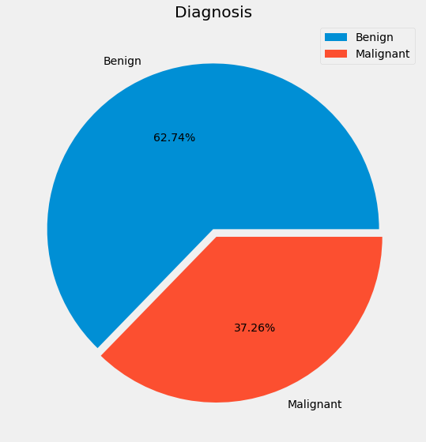

```python
labels = ["Benign", "Malignant"]
sizes = cancer_data["diagnosis"].value_counts()
explode = [0, 0.05]
plt.rcParams['figure.figsize'] = (9, 9)
plt.pie(sizes, labels=labels, explode=explode, autopct="%1.2f%%")
plt.title("Diagnosis")
plt.legend()
plt.show()
```

### Violinplot (first ten features)

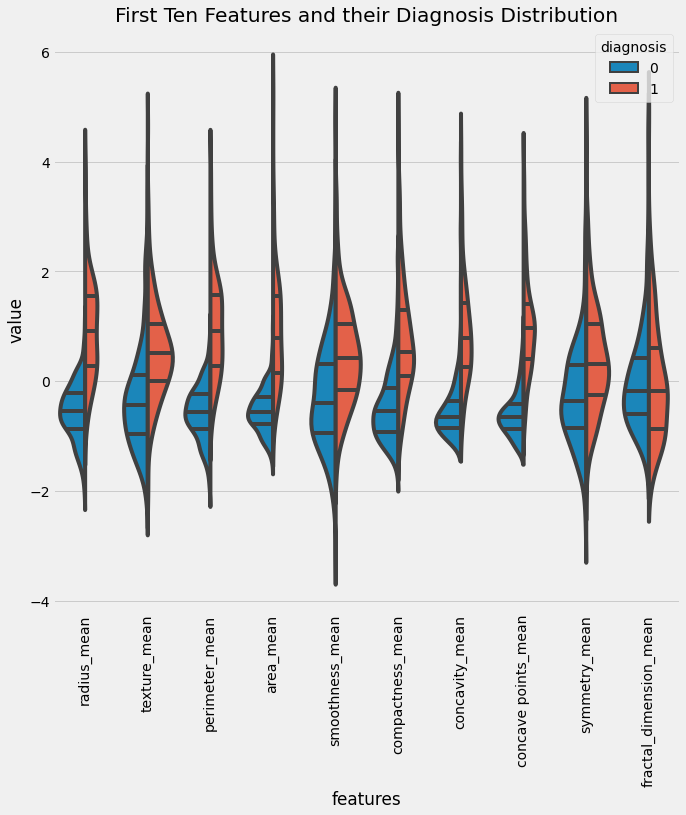

```python
target = y
features = X
data_standardized = (features - features.mean()) / (features.std())
data = pd.concat([y, data_standardized.iloc[:,0:10]], axis=1)
data = pd.melt(data, id_vars="diagnosis", var_name="features", value_name="value")
plt.figure(figsize=(10,10))
sns.violinplot(x="features", y="value", hue="diagnosis", data=data, split=True, inner="quart")
plt.xticks(rotation=90)
plt.title("First Ten Features and their Diagnosis Distribution")
plt.show()
```

### Violinplot (second ten features)

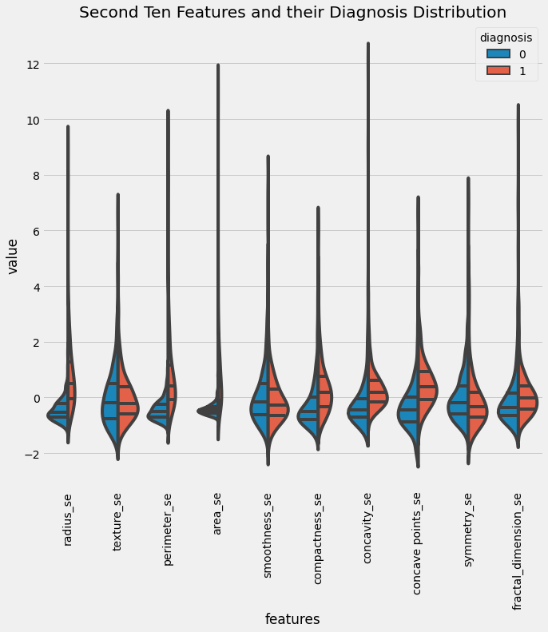

```python
data = pd.concat([y, data_standardized.iloc[:,10:20]], axis=1)
data = pd.melt(data, id_vars="diagnosis", var_name="features", value_name="value")
plt.figure(figsize=(10,10))
sns.violinplot(x="features", y="value", hue="diagnosis", data=data, split=True, inner="quart")
plt.xticks(rotation=90)
plt.title("Second Ten Features and their Diagnosis Distribution")
plt.show()
```

### Violinplot (last ten features)

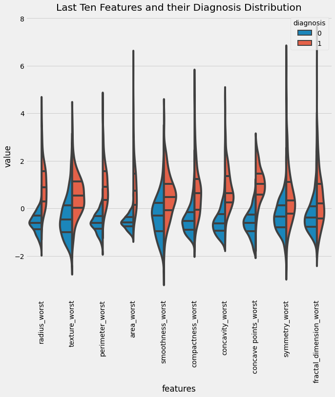

```python
data = pd.concat([y, data_standardized.iloc[:,20:31]], axis=1)
data = pd.melt(data, id_vars="diagnosis", var_name="features", value_name="value")
plt.figure(figsize=(10,10))
sns.violinplot(x="features", y="value", hue="diagnosis", data=data, split=True, inner="quart")
plt.xticks(rotation=90)
plt.title("Last Ten Features and their Diagnosis Distribution")
plt.show()
```

### Correlation Between 2 Columns

`concavity_worst` and `concave points_worst` *Columns picked to see if there was any correlation since their names are similar.*

```
Correlation with Two Similarly Named Features
```

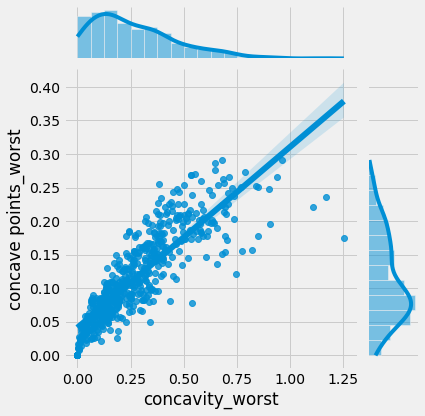

```python
sns.jointplot(X.loc[:,"concavity_worst"], X.loc[:,"concave points_worst"], kind="reg")
print("Correlation with Two Similarly Named Features")
plt.show()
```

### Correlation Between Multiple Columns

```
Correlation Between Three or more Features
```

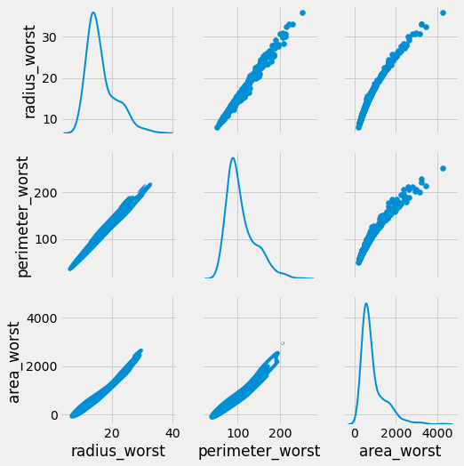

```python
columns = X.loc[:, ["radius_worst", "perimeter_worst", "area_worst"]]
grid = sns.PairGrid(columns, diag_sharey=False)
grid.map_upper(plt.scatter)
grid.map_lower(sns.kdeplot)
grid.map_diag(sns.kdeplot, lw=2)
print("Correlation Between Three or more Features")
plt.show()
```

### Swarmplot (first ten features)

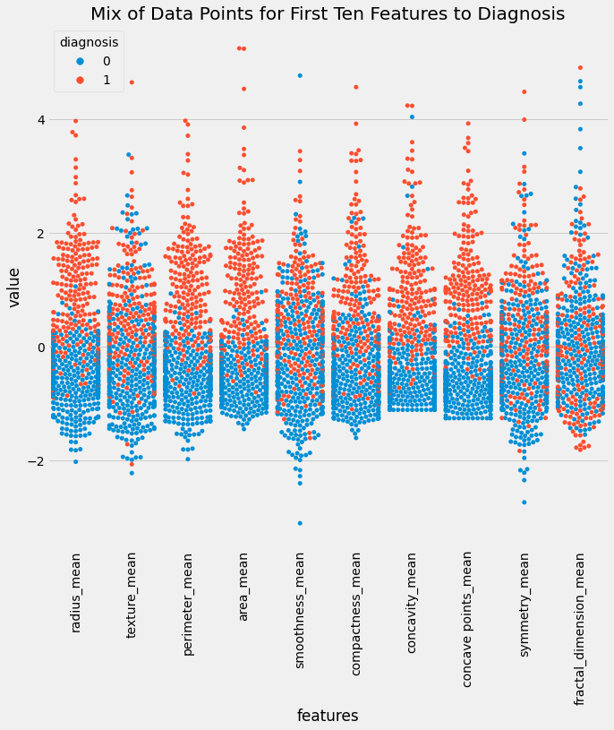

```python
data = pd.concat([y, data_standardized.iloc[:, 0:10]], axis=1)
data = pd.melt(data, id_vars="diagnosis", var_name="features", value_name="value")
plt.figure(figsize=(10,10))
sns.swarmplot(x="features", y="value", hue="diagnosis", data=data)
plt.xticks(rotation=90)
plt.title("Mix of Data Points for First Ten Features to Diagnosis")
plt.show()
```

### Swarmplot (second ten features)

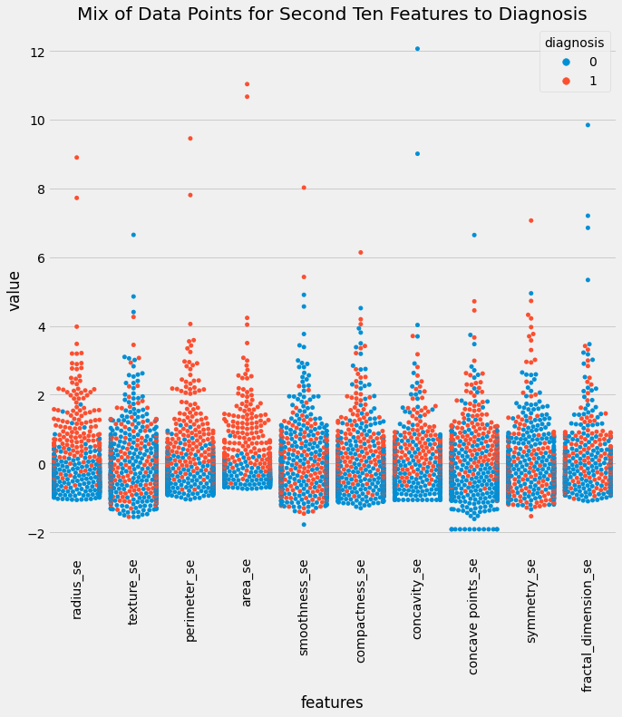

```python
data = pd.concat([y, data_standardized.iloc[:, 10:20]], axis=1)
data = pd.melt(data, id_vars="diagnosis", var_name="features", value_name="value")
plt.figure(figsize=(10,10))
sns.swarmplot(x="features", y="value", hue="diagnosis", data=data)
plt.xticks(rotation=90)
plt.title("Mix of Data Points for Second Ten Features to Diagnosis")
plt.show()
```

### Swarmplot (last ten features)

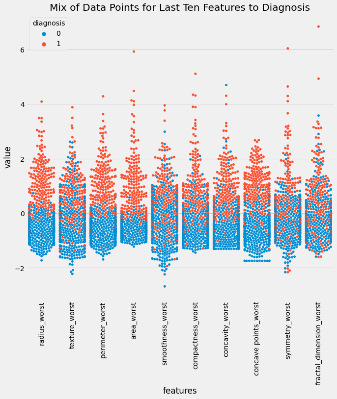

```python
data = pd.concat([y, data_standardized.iloc[:, 20:31]], axis=1)
data = pd.melt(data, id_vars="diagnosis", var_name="features", value_name="value")
plt.figure(figsize=(10,10))
sns.swarmplot(x="features", y="value", hue="diagnosis", data=data)
plt.xticks(rotation=90)
plt.title("Mix of Data Points for Last Ten Features to Diagnosis")
plt.show()
```

### Heatmap

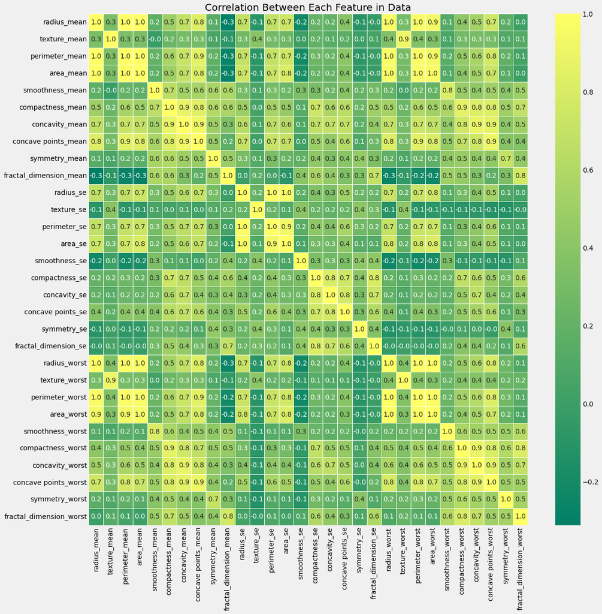

```python
figure, ax = plt.subplots(figsize=(18, 18))
sns.heatmap(X.corr(), annot=True, linewidths=.5, fmt= ".1f",ax=ax, cmap="summer")
plt.title("Correlation Between Each Feature in Data")
plt.show()
```

```python
X_train, X_test, y_train, y_test = train_test_split(X, y, test_size=0.33, random_state=42)
```

```python
rfc = RandomForestClassifier()
rfe = RFE(estimator=rfc, n_features_to_select=5, step=1)
rfe = rfe.fit(X_train, y_train)
```

```python
print(f"Best features: {X_train.columns[rfe.support_]}")
```

```
Best features: Index(['concave points_mean', 'radius_worst', 'perimeter_worst', 'area_worst',
       'concave points_worst'],
      dtype='object')
```

```python
predictions = rfe.predict(X_test)
print(f"Accuracy Score: {accuracy_score(y_test, predictions)}")
print(f"F1 Score: {f1_score(y_test, predictions)}")
print(f"Confusion Matrix:\n {confusion_matrix(y_test, predictions)}")
```

```
Accuracy Score: 0.9627659574468085
F1 Score: 0.9465648854961832
Confusion Matrix:
 [[119   2]
 [  5  62]]
```

## Model Performance

**Accuracy**: `96%`

**F1 Score** (*as close to 1 as possible*): `0.95`

Here is the complete model as a functioin:

```
import pandas as pd
from sklearn.model_selection import train_test_split
from sklearn.ensemble import RandomForestClassifier
from sklearn.feature_selection import RFE

def cancer_classification(file):
    # Note: `file` is the full path on computer that points to the CSV cancer data.
    cancer_data = pd.read_csv(file)
    # Read NOTE at bottom regarding the code from here till "==="
    diagnosis = []
    for i in range(len(cancer_data["diagnosis"])):
        if cancer_data["diagnosis"][i] == "B":
            diagnosis.append(0)
        else:
            diagnosis.append(1)
    del cancer_data["diagnosis"]
    cancer_data["diagnosis"] = diagnosis
    # ===

    X = cancer_data.drop("diagnosis", axis=1)
    y = cancer_data["diagnosis"]

    X_train, X_test, y_train, y_test = train_test_split(X, y, test_size=0.33, random_state=42)

    rfc = RandomForestClassifier()
    rfe = RFE(estimator=rfc, n_features_to_select=5, step=1)
    rfe = rfe.fit(X_train, y_train)

    return rfe.predict(X_test)
```

**NOTE: The substitution algorithm for `diagnosis` is included in the function to model all previous steps. In reality, that part should be taken out as there is no diagnosis yet, that is what the model is predicting.**

## Closing Information

### Model

For the model to work properly, new data should be categorized in the same columns as those of the original data. All columns should be either `int64` or `float64`.

### Data

The data used in this analysis can be found [here](https://www.kaggle.com/uciml/breast-cancer-wisconsin-data/code?datasetId=180&sortBy=voteCount)

### Author

All code by: `Gautam Pradhan`

Created by: Gautam Pradhan

Source Code [here](https://github.com/wcpss-gp/wcpss-gp.github.io).